# Sprint_2_Development

Artificial Intelligence for Business Decisions and Transformation

CSCN8030 - Spring 2024 - Section 2

Professor: Glaucia Melo dos Santos, PhD

Group 4 - Members:

Krishna Kumar, Hemasree  
Shijin, Jency  
Fernandez, Arcadio

## Sprint 2 Development:

# Project: ML-Driven Customer Segmentation for Brazilian eCommerce

Brazilian E-Commerce Public Dataset by Olist (2016 to 2018)

# 1. Introduction: A brief introduction to the problem, libraries and obtaining the data.

### 1.1. A brief introduction to the problem

Brazilian E-Commerce Public Dataset by Olist

This is a Brazilian e-commerce public dataset of orders made at Olist Store. The dataset has information on 100k orders from 2016 to 2018 made at multiple marketplaces in Brazil. Its features allow customers to view orders from multiple dimensions: from order status, price, payment, and freight performance to customer location, product attributes, and, finally, customer reviews. Olist also released a geolocation dataset that relates Brazilian zip codes to latitude and longitude coordinates.

Olist connects small businesses across Brazil to channels without hassle and with a single contract. Those merchants can sell their products through the Olist Store and ship them directly to the customers using Olist logistics partners. See more on our website: www.olist.com

After a customer purchases the product from Olist Store, the seller is notified to fulfill that order. Once the customer receives the product or the estimated delivery date is due, the customer gets a satisfaction survey by email, in which he can give a note about the purchase experience and write down some comments.

Olist Store's competitors are other e-commerce companies such as Mercado Livre, Lojas Americanas, Via Varejo, and Amazon.

This is real commercial data; it has been anonymized, and references to the companies and partners in the review text have been replaced.

Our work will focus on data exploration, geospatial analysis and customer segmentation.

### 1.2. Importing all the essential libraries and sub modules

```python
! pip install holoviews
! pip install geoviews
! pip install datashader
! pip install jupyter_bokeh
```

```python
# Import Libraries
import numpy as np
import pandas as pd
import os
import seaborn as sns
from matplotlib import pyplot as plt
from bokeh.plotting import figure, show
from jupyter_bokeh import BokehModel
import holoviews as hv
```

```python
# Import libraries for geospatial analysis
# Reference - https://www.kaggle.com/code/andresionek/geospatial-analysis-of-brazilian-e-commerce?scriptVersionId=7894200&cellId=13
# plot wtih holoviews + datashader - bokeh with map background
import holoviews as hv
import geoviews as gv
import datashader as ds
from colorcet import fire, rainbow, bgy, bjy, bkr, kb, kr
from datashader.colors import colormap_select, Greys9
from datashader.utils import lnglat_to_meters as webm
from holoviews.streams import RangeXY
from holoviews.operation.datashader import datashade, dynspread, rasterize
from bokeh.io import push_notebook, show, output_notebook
output_notebook()
hv.extension('bokeh')

%opts Overlay [width=800 height=600 toolbar='above' xaxis=None yaxis=None]
%opts QuadMesh [tools=['hover'] colorbar=True] (alpha=0 hover_alpha=0.2)

T = 0.05
PX = 1

def plot_map(data, label, agg_data, agg_name, cmap):
    url="http://server.arcgisonline.com/ArcGIS/rest/services/Canvas/World_Dark_Gray_Base/MapServer/tile/{Z}/{Y}/{X}.png"
    geomap = gv.WMTS(url)
    points = hv.Points(gv.Dataset(data, kdims=['x', 'y'], vdims=[agg_name]))
    agg = datashade(points, element_type=gv.Image, aggregator=agg_data, cmap=cmap)
    zip_codes = dynspread(agg, threshold=T, max_px=PX)
    hover = hv.util.Dynamic(rasterize(points, aggregator=agg_data, width=50, height=25, streams=[RangeXY]), operation=hv.QuadMesh)
    hover = hover.options(cmap=cmap)
    img = geomap * zip_codes * hover
    img = img.relabel(label)
    return img
```

Loading BokehJS ...

### 1.3. Obtaining the Data

```python
import pandas as pd

# Load the data from CSV files to dataframe
data_path = r'Data\Brazilian_Ecommerce_dataset\\'
customer_df = pd.read_csv(data_path + 'olist_customers_dataset.csv')
geolocation_df = pd.read_csv(data_path + 'olist_geolocation_dataset.csv')
order_items_df = pd.read_csv(data_path + 'olist_order_items_dataset.csv')
order_payments_df = pd.read_csv(data_path + 'olist_order_payments_dataset.csv')
order_reviews_df = pd.read_csv(data_path + 'olist_order_reviews_dataset.csv')
orders_df = pd.read_csv(data_path + 'olist_orders_dataset.csv')
products_df = pd.read_csv(data_path + 'olist_products_dataset.csv')
sellers_df = pd.read_csv(data_path + 'olist_sellers_dataset.csv')
product_category_name_translation_df = pd.read_csv(data_path + 'product_category_name_translation.csv')
```

```python
# Merge the datasets
ecommerce_df = orders_df.merge(order_items_df, on='order_id', how='left')
ecommerce_df = ecommerce_df.merge(order_payments_df, on='order_id', how='outer')
ecommerce_df = ecommerce_df.merge(order_reviews_df, on='order_id', how='outer')
ecommerce_df = ecommerce_df.merge(products_df, on='product_id', how='outer')
ecommerce_df = ecommerce_df.merge(customer_df, on='customer_id', how='outer')
ecommerce_df = ecommerce_df.merge(sellers_df, on='seller_id', how='outer')
ecommerce_df = ecommerce_df.merge(product_category_name_translation_df, on='product_category_name', how='outer')
```

```python
display(ecommerce_df)
```

|  | order_id | customer_id | order_status | order_purchase_timestamp | order_approved_at | order_delivered_carrier_date | order_delivered_customer_date | order_estimated_delivery_date | order_item_id | product_id | ... | product_height_cm | product_width_cm | customer_unique_id | customer_zip_code_prefix | customer_city | customer_state | seller_zip_code_prefix | seller_city | seller_state | product_category_name_english |
| --- | --- | --- | --- | --- | --- | --- | --- | --- | --- | --- | --- | --- | --- | --- | --- | --- | --- | --- | --- | --- | --- |
| 0 | e481f51cbdc54678b7cc49136f2d6af7 | 9ef432eb6251297304e76186b10a928d | delivered | 2017-10-02 10:56:33 | 2017-10-02 11:07:15 | 2017-10-04 19:55:00 | 2017-10-10 21:25:13 | 2017-10-18 00:00:00 | 1.0 | 87285b34884572647811a353c7ac498a | ... | 8.0 | 13.0 | 7c396fd4830fd04220f754e42b4e5bff | 3149 | sao paulo | SP | 9350.0 | maua | SP | housewares |
| 1 | e481f51cbdc54678b7cc49136f2d6af7 | 9ef432eb6251297304e76186b10a928d | delivered | 2017-10-02 10:56:33 | 2017-10-02 11:07:15 | 2017-10-04 19:55:00 | 2017-10-10 21:25:13 | 2017-10-18 00:00:00 | 1.0 | 87285b34884572647811a353c7ac498a | ... | 8.0 | 13.0 | 7c396fd4830fd04220f754e42b4e5bff | 3149 | sao paulo | SP | 9350.0 | maua | SP | housewares |
| 2 | e481f51cbdc54678b7cc49136f2d6af7 | 9ef432eb6251297304e76186b10a928d | delivered | 2017-10-02 10:56:33 | 2017-10-02 11:07:15 | 2017-10-04 19:55:00 | 2017-10-10 21:25:13 | 2017-10-18 00:00:00 | 1.0 | 87285b34884572647811a353c7ac498a | ... | 8.0 | 13.0 | 7c396fd4830fd04220f754e42b4e5bff | 3149 | sao paulo | SP | 9350.0 | maua | SP | housewares |
| 3 | 128e10d95713541c87cd1a2e48201934 | a20e8105f23924cd00833fd87daa0831 | delivered | 2017-08-15 18:29:31 | 2017-08-15 20:05:16 | 2017-08-17 15:28:33 | 2017-08-18 14:44:43 | 2017-08-28 00:00:00 | 1.0 | 87285b34884572647811a353c7ac498a | ... | 8.0 | 13.0 | 3a51803cc0d012c3b5dc8b7528cb05f7 | 3366 | sao paulo | SP | 9350.0 | maua | SP | housewares |
| 4 | 0e7e841ddf8f8f2de2bad69267ecfbcf | 26c7ac168e1433912a51b924fbd34d34 | delivered | 2017-08-02 18:24:47 | 2017-08-02 18:43:15 | 2017-08-04 17:35:43 | 2017-08-07 18:30:01 | 2017-08-15 00:00:00 | 1.0 | 87285b34884572647811a353c7ac498a | ... | 8.0 | 13.0 | ef0996a1a279c26e7ecbd737be23d235 | 2290 | sao paulo | SP | 9350.0 | maua | SP | housewares |
| ... | ... | ... | ... | ... | ... | ... | ... | ... | ... | ... | ... | ... | ... | ... | ... | ... | ... | ... | ... | ... | ... |
| 119138 | 442a41b00a8a8bda35511fdf1eb65cc5 | e42e2e8642f9c09100b6667e321c2811 | invoiced | 2018-07-11 22:27:32 | 2018-07-11 22:45:43 | NaN | NaN | 2018-07-20 00:00:00 | 1.0 | 5b668636d65ddf4e4109c6d8fb13ea56 | ... | 2.0 | 30.0 | f84487fed78baf25458828c99a2daa5d | 3402 | sao paulo | SP | 5201.0 | sao paulo | SP | books_imported |
| 119139 | 1dbff949801376b8795a093d31cfe205 | 0cbd2df3d6e9d8b1eaf5cfefc44886bc | delivered | 2018-05-16 14:50:54 | 2018-05-16 15:18:42 | 2018-05-18 12:10:00 | 2018-05-21 17:14:08 | 2018-05-28 00:00:00 | 1.0 | 90797f195eb7bb9dae050697a25f35ce | ... | 2.0 | 23.0 | 1de8fb735d8252498d9a2f82a68c57e0 | 9411 | ribeirao pires | SP | 5201.0 | sao paulo | SP | books_imported |
| 119140 | 6775b950cdc4da0ce39b261032f92c84 | c4d135422be0d4333f506acde8af9419 | delivered | 2018-06-13 12:19:26 | 2018-06-13 17:39:14 | 2018-06-15 13:09:00 | 2018-06-16 17:48:30 | 2018-06-28 00:00:00 | 1.0 | 3e72533d34a1779d818ac8a73403387c | ... | 2.0 | 23.0 | 5f684afb3d1a02f2787e80cb0eee6e02 | 2927 | sao paulo | SP | 5201.0 | sao paulo | SP | books_imported |
| 119141 | 73d60420cd1a179b2d8887d538efe4c2 | 65d9213dfa004c17dc126503e106e4a3 | delivered | 2018-08-07 10:52:58 | 2018-08-07 11:05:18 | 2018-08-08 08:31:00 | 2018-08-22 17:02:23 | 2018-09-04 00:00:00 | 1.0 | 078b7149a32b479d3cbf1649fea0172c | ... | 14.0 | 16.0 | 78275e95a4296105923051e0ad4577b3 | 65700 | bacabal | MA | 22745.0 | rio de janeiro | RJ | books_imported |
| 119142 | f5cf5716413185387030a378bdd46ebe | ff95df9a387c8d032a2ca6887cf77236 | processing | 2017-02-19 22:31:47 | 2017-02-19 22:45:13 | NaN | NaN | 2017-03-21 00:00:00 | 1.0 | a853bf1a5f8d9f04f5df123168164720 | ... | 9.0 | 18.0 | 5166dddbe02c6e2279cd1305a88b0c99 | 35519 | nova serrana | MG | 1309.0 | sao paulo | SP | books_imported |

119143 rows × 40 columns

# 2. Exploratory data analysis - EDA

## 2.1. Basic data analysis

```python
# Checking the dataset shape
print(ecommerce_df.shape)
```

```
(119143, 40)
```

The dataframe has 119,143 entries (rows) and 40 columns.

```python
# Viewing the first few rows of the merged dataset
ecommerce_df.head()
```

|  | order_id | customer_id | order_status | order_purchase_timestamp | order_approved_at | order_delivered_carrier_date | order_delivered_customer_date | order_estimated_delivery_date | order_item_id | product_id | ... | product_height_cm | product_width_cm | customer_unique_id | customer_zip_code_prefix | customer_city | customer_state | seller_zip_code_prefix | seller_city | seller_state | product_category_name_english |
| --- | --- | --- | --- | --- | --- | --- | --- | --- | --- | --- | --- | --- | --- | --- | --- | --- | --- | --- | --- | --- | --- |
| 0 | e481f51cbdc54678b7cc49136f2d6af7 | 9ef432eb6251297304e76186b10a928d | delivered | 2017-10-02 10:56:33 | 2017-10-02 11:07:15 | 2017-10-04 19:55:00 | 2017-10-10 21:25:13 | 2017-10-18 00:00:00 | 1.0 | 87285b34884572647811a353c7ac498a | ... | 8.0 | 13.0 | 7c396fd4830fd04220f754e42b4e5bff | 3149 | sao paulo | SP | 9350.0 | maua | SP | housewares |
| 1 | e481f51cbdc54678b7cc49136f2d6af7 | 9ef432eb6251297304e76186b10a928d | delivered | 2017-10-02 10:56:33 | 2017-10-02 11:07:15 | 2017-10-04 19:55:00 | 2017-10-10 21:25:13 | 2017-10-18 00:00:00 | 1.0 | 87285b34884572647811a353c7ac498a | ... | 8.0 | 13.0 | 7c396fd4830fd04220f754e42b4e5bff | 3149 | sao paulo | SP | 9350.0 | maua | SP | housewares |
| 2 | e481f51cbdc54678b7cc49136f2d6af7 | 9ef432eb6251297304e76186b10a928d | delivered | 2017-10-02 10:56:33 | 2017-10-02 11:07:15 | 2017-10-04 19:55:00 | 2017-10-10 21:25:13 | 2017-10-18 00:00:00 | 1.0 | 87285b34884572647811a353c7ac498a | ... | 8.0 | 13.0 | 7c396fd4830fd04220f754e42b4e5bff | 3149 | sao paulo | SP | 9350.0 | maua | SP | housewares |
| 3 | 128e10d95713541c87cd1a2e48201934 | a20e8105f23924cd00833fd87daa0831 | delivered | 2017-08-15 18:29:31 | 2017-08-15 20:05:16 | 2017-08-17 15:28:33 | 2017-08-18 14:44:43 | 2017-08-28 00:00:00 | 1.0 | 87285b34884572647811a353c7ac498a | ... | 8.0 | 13.0 | 3a51803cc0d012c3b5dc8b7528cb05f7 | 3366 | sao paulo | SP | 9350.0 | maua | SP | housewares |
| 4 | 0e7e841ddf8f8f2de2bad69267ecfbcf | 26c7ac168e1433912a51b924fbd34d34 | delivered | 2017-08-02 18:24:47 | 2017-08-02 18:43:15 | 2017-08-04 17:35:43 | 2017-08-07 18:30:01 | 2017-08-15 00:00:00 | 1.0 | 87285b34884572647811a353c7ac498a | ... | 8.0 | 13.0 | ef0996a1a279c26e7ecbd737be23d235 | 2290 | sao paulo | SP | 9350.0 | maua | SP | housewares |

5 rows × 40 columns

```python
ecommerce_df.info()
```

```
<class 'pandas.core.frame.DataFrame'>
RangeIndex: 119143 entries, 0 to 119142
Data columns (total 40 columns):
 #   Column                         Non-Null Count   Dtype
---  ------                         --------------   -----
 0   order_id                       119143 non-null  object
 1   customer_id                    119143 non-null  object
 2   order_status                   119143 non-null  object
 3   order_purchase_timestamp       119143 non-null  object
 4   order_approved_at              118966 non-null  object
 5   order_delivered_carrier_date   117057 non-null  object
 6   order_delivered_customer_date  115722 non-null  object
 7   order_estimated_delivery_date  119143 non-null  object
 8   order_item_id                  118310 non-null  float64
 9   product_id                     118310 non-null  object
```

[output cut: 32 more lines]

```python
ecommerce_df.dtypes
```

```
order_id                          object
customer_id                       object
order_status                      object
order_purchase_timestamp          object
order_approved_at                 object
order_delivered_carrier_date      object
order_delivered_customer_date     object
order_estimated_delivery_date     object
order_item_id                    float64
product_id                        object
seller_id                         object
shipping_limit_date               object
price                            float64
freight_value                    float64
payment_sequential               float64
payment_type                      object
payment_installments             float64
payment_value                    float64
review_id                         object
review_score                     float64
review_comment_title              object
review_comment_message            object
review_creation_date              object
review_answer_timestamp           object
product_category_name             object
product_name_lenght              float64
product_description_lenght       float64
product_photos_qty               float64
product_weight_g                 float64
product_length_cm                float64
product_height_cm                float64
product_width_cm                 float64
customer_unique_id                object
customer_zip_code_prefix           int64
customer_city                     object
customer_state                    object
seller_zip_code_prefix           float64
seller_city                       object
seller_state                      object
product_category_name_english     object
dtype: object
```

```python
ecommerce_df.nunique()
```

```
order_id                         99441
customer_id                      99441
order_status                         8
order_purchase_timestamp         98875
order_approved_at                90733
order_delivered_carrier_date     81018
order_delivered_customer_date    95664
order_estimated_delivery_date      459
order_item_id                       21
product_id                       32951
seller_id                         3095
shipping_limit_date              93318
price                             5968
freight_value                     6999
payment_sequential                  29
payment_type                         5
payment_installments                24
payment_value                    29077
review_id                        98410
review_score                         5
review_comment_title              4527
review_comment_message           36159
review_creation_date               636
review_answer_timestamp          98248
product_category_name               73
product_name_lenght                 66
product_description_lenght        2960
product_photos_qty                  19
product_weight_g                  2204
product_length_cm                   99
product_height_cm                  102
product_width_cm                    95
customer_unique_id               96096
customer_zip_code_prefix         14994
customer_city                     4119
customer_state                      27
seller_zip_code_prefix            2246
seller_city                        611
seller_state                        23
product_category_name_english       71
dtype: int64
```

```python
ecommerce_df.order_status.value_counts()
```

```
order_status
delivered      115723
shipped          1256
canceled          750
unavailable       652
invoiced          378
processing        376
created             5
approved            3
Name: count, dtype: int64
```

## 2.2. Statistical analysis

```python
ecommerce_df.describe(include='all')
```

|  | order_id | customer_id | order_status | order_purchase_timestamp | order_approved_at | order_delivered_carrier_date | order_delivered_customer_date | order_estimated_delivery_date | order_item_id | product_id | ... | product_height_cm | product_width_cm | customer_unique_id | customer_zip_code_prefix | customer_city | customer_state | seller_zip_code_prefix | seller_city | seller_state | product_category_name_english |
| --- | --- | --- | --- | --- | --- | --- | --- | --- | --- | --- | --- | --- | --- | --- | --- | --- | --- | --- | --- | --- | --- |
| count | 119143 | 119143 | 119143 | 119143 | 118966 | 117057 | 115722 | 119143 | 118310.000000 | 118310 | ... | 118290.000000 | 118290.000000 | 119143 | 119143.000000 | 119143 | 119143 | 118310.000000 | 118310 | 118310 | 116576 |
| unique | 99441 | 99441 | 8 | 98875 | 90733 | 81018 | 95664 | 459 | NaN | 32951 | ... | NaN | NaN | 96096 | NaN | 4119 | 27 | NaN | 611 | 23 | 71 |
| top | 895ab968e7bb0d5659d16cd74cd1650c | 270c23a11d024a44c896d1894b261a83 | delivered | 2017-08-08 20:26:31 | 2017-08-08 20:43:31 | 2017-08-10 11:58:14 | 2017-08-14 12:46:18 | 2017-12-20 00:00:00 | NaN | aca2eb7d00ea1a7b8ebd4e68314663af | ... | NaN | NaN | 9a736b248f67d166d2fbb006bcb877c3 | NaN | sao paulo | SP | NaN | sao paulo | SP | bed_bath_table |
| freq | 63 | 63 | 115723 | 63 | 63 | 63 | 63 | 663 | NaN | 536 | ... | NaN | NaN | 75 | NaN | 18875 | 50265 | NaN | 29293 | 84377 | 11988 |
| mean | NaN | NaN | NaN | NaN | NaN | NaN | NaN | NaN | 1.196543 | NaN | ... | 16.619706 | 23.074799 | NaN | 35033.451298 | NaN | NaN | 24442.410413 | NaN | NaN | NaN |
| std | NaN | NaN | NaN | NaN | NaN | NaN | NaN | NaN | 0.699489 | NaN | ... | 13.453584 | 11.749139 | NaN | 29823.198969 | NaN | NaN | 27573.004511 | NaN | NaN | NaN |
| min | NaN | NaN | NaN | NaN | NaN | NaN | NaN | NaN | 1.000000 | NaN | ... | 2.000000 | 6.000000 | NaN | 1003.000000 | NaN | NaN | 1001.000000 | NaN | NaN | NaN |
| 25% | NaN | NaN | NaN | NaN | NaN | NaN | NaN | NaN | 1.000000 | NaN | ... | 8.000000 | 15.000000 | NaN | 11250.000000 | NaN | NaN | 6429.000000 | NaN | NaN | NaN |
| 50% | NaN | NaN | NaN | NaN | NaN | NaN | NaN | NaN | 1.000000 | NaN | ... | 13.000000 | 20.000000 | NaN | 24240.000000 | NaN | NaN | 13660.000000 | NaN | NaN | NaN |
| 75% | NaN | NaN | NaN | NaN | NaN | NaN | NaN | NaN | 1.000000 | NaN | ... | 20.000000 | 30.000000 | NaN | 58475.000000 | NaN | NaN | 27972.000000 | NaN | NaN | NaN |
| max | NaN | NaN | NaN | NaN | NaN | NaN | NaN | NaN | 21.000000 | NaN | ... | 105.000000 | 118.000000 | NaN | 99990.000000 | NaN | NaN | 99730.000000 | NaN | NaN | NaN |

11 rows × 40 columns

## 2.3. Customer analysis

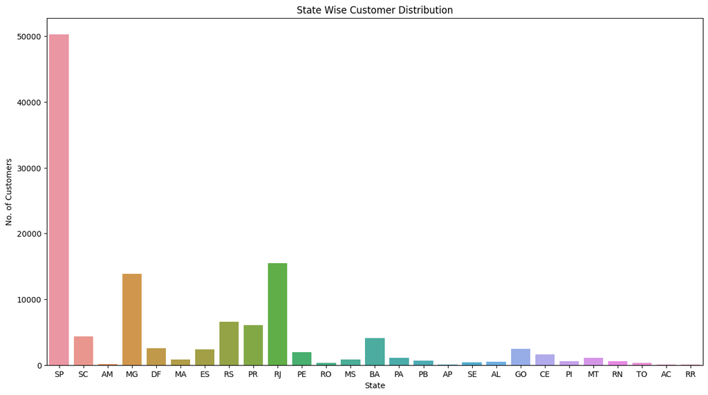

```python
# plotting state wise customer distribution
plt.figure(figsize=(15,8))
sns.countplot(x='customer_state', data=ecommerce_df)
plt.title('State Wise Customer Distribution')
plt.xlabel('State')
plt.ylabel('No. of Customers')
```

The most number of customer is from state code 'SP' (São Paulo) which is followed by 'RJ' and 'MG', which are all situated in the SouthEast region of Brazil. This could be due to a variety of factors such as population size, economic activity, or the nature of the business.

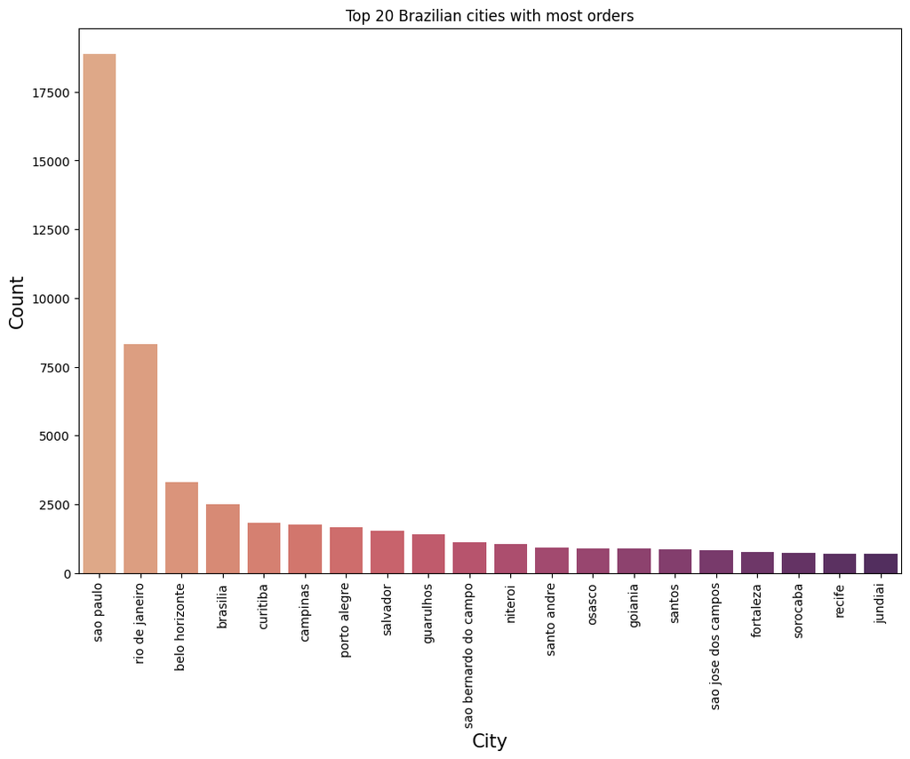

```python
# plotting the top 20 cities with most orders
top_cities = ecommerce_df['customer_city'].value_counts().head(20)
x = top_cities.index
y = top_cities.values
# Create the plot
plt.figure(figsize=(12,8))
sns.barplot(x=x, y=y, palette='flare')
plt.title('Top 20 Brazilian cities with most orders')
plt.xlabel('City', fontsize=15)
plt.ylabel('Count', fontsize=15)
plt.xticks(rotation = 'vertical')
plt.show()
```

The top 20 Brazilian cities with the most orders is a great way to understand customer base. Again the most number of orders is from state 'SP' (São Paulo)

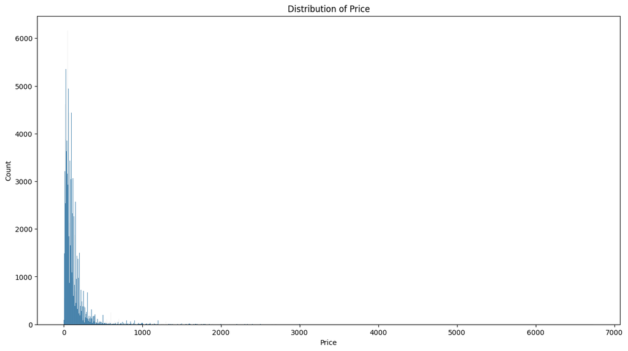

```python
# plotting the price distribution
plt.figure(figsize=(15,8))
sns.histplot(x='price', data=ecommerce_df)
plt.title('Distribution of Price')
plt.xlabel('Price')
```

Most of the prices are clustered towards the lower end of the price range ie. under 1000 Brazilian Reals. Also indicates that there are fewer instances of high-priced items in this dataset.

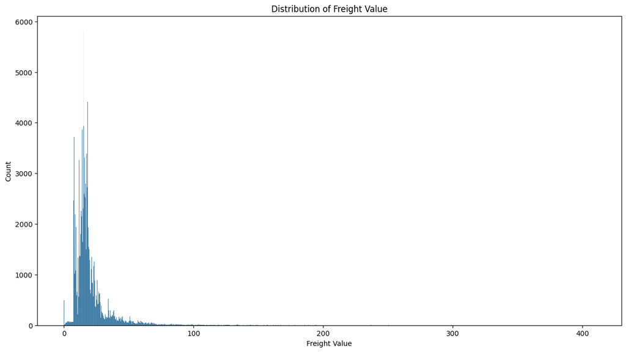

```python
# plotting the frieght distribution
plt.figure(figsize=(15,8))
sns.histplot(x='freight_value', data=ecommerce_df)
plt.title('Distribution of Freight Value')
plt.xlabel('Freight Value')
```

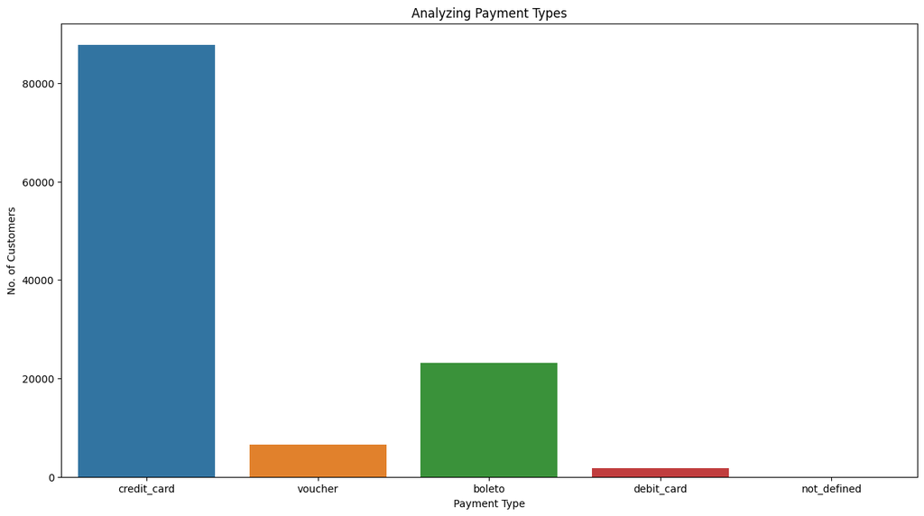

```python
# Analyzing the payment methods chosen by different customers
plt.figure(figsize=(15,8))
sns.countplot(x='payment_type', data=ecommerce_df)
plt.title('Analyzing Payment Types')
plt.xlabel('Payment Type')
plt.ylabel('No. of Customers')
```

The plot indicates that ‘credit_card’ payment type is significantly more popular than the others. This could indicate that most customers prefer to pay with credit cards over other methods like vouchers, boletos, or debit cards.

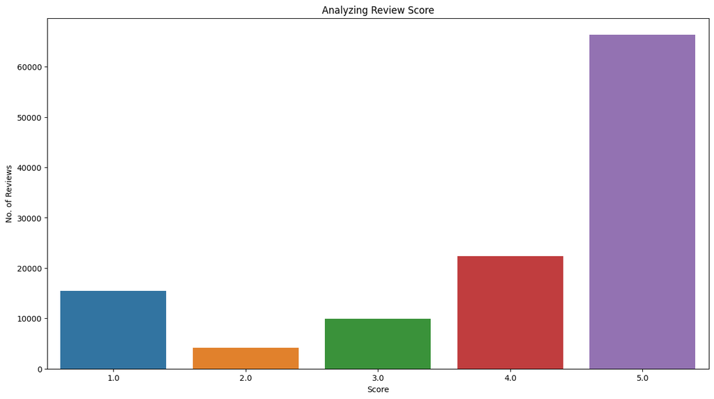

```python
# Analyzing the review score given by customers
plt.figure(figsize=(15,8))
sns.countplot(x='review_score', data=ecommerce_df)
plt.title('Analyzing Review Score')
plt.xlabel('Score')
plt.ylabel('No. of Reviews')
```

Useful to review the Customer satisfaction. Most customers are satisfied with the service and have given 4 and 5 ratings accordingly. Followed by that, many customers have given a raitng of 1, which means that they are dissapointed with the service.

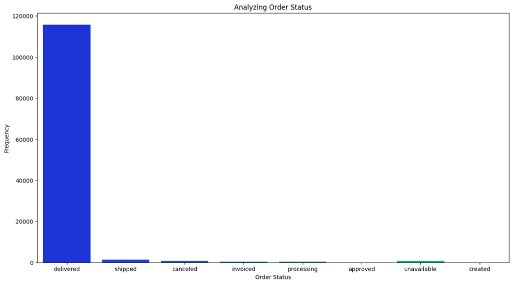

```python
# analyzing the order status
plt.figure(figsize=(15,8))
sns.countplot(x='order_status', palette='winter', data=ecommerce_df)
plt.title('Analyzing Order Status')
plt.xlabel('Order Status')
plt.ylabel('Frequency')
```

The ‘delivered’ status is significantly more common than the others. This indicates that most orders in the dataset have been successfully delivered.

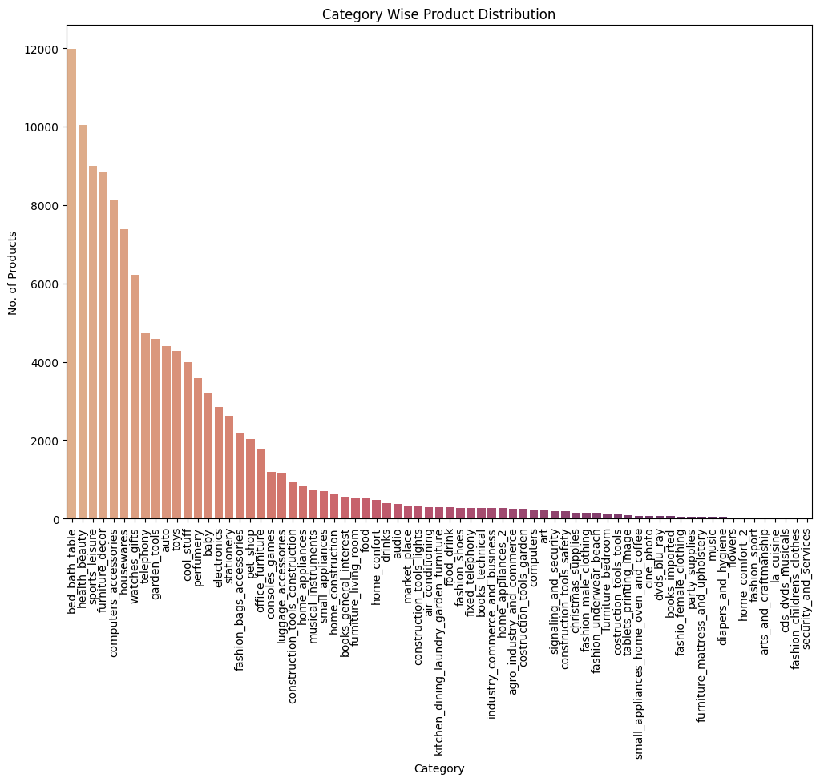

```python
# plotting the category wise distribution of products
product_category_counts = ecommerce_df['product_category_name_english'].value_counts()
x = product_category_counts.index
y = product_category_counts.values
# plotting the category wise distribution of products
plt.figure(figsize=(12,8))
sns.barplot(x=x,y =y , data=ecommerce_df,order=x, palette='flare')
plt.title('Category Wise Product Distribution')
plt.xlabel('Category')
plt.ylabel('No. of Products')
plt.xticks(rotation = 'vertical')
plt.show()
```

This plot is usefull to understand the variety of products in the dataset. Most product are from bed_bath_table category

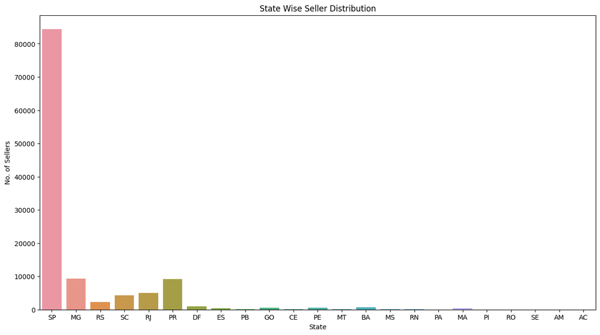

```python
# plotting state wise seller distribution
plt.figure(figsize=(15,8))
sns.countplot(x='seller_state', data=ecommerce_df)
plt.title('State Wise Seller Distribution')
plt.xlabel('State')
plt.ylabel('No. of Sellers')
```

Most number of sellers are from state 'SP' (Sau Paulo), which makes sense since the number of customers in that state was also very high.

## 2.5. Geospatial Analysis

```python
geolocation_df.shape
```

```
(1000163, 5)
```

```python
geolocation_df.nunique()
```

```
geolocation_zip_code_prefix     19015
geolocation_lat                717360
geolocation_lng                717613
geolocation_city                 8011
geolocation_state                  27
dtype: int64
```

```python
geolocation_df.info()
```

```
<class 'pandas.core.frame.DataFrame'>
RangeIndex: 1000163 entries, 0 to 1000162
Data columns (total 5 columns):
 #   Column                       Non-Null Count    Dtype
---  ------                       --------------    -----
 0   geolocation_zip_code_prefix  1000163 non-null  int64
 1   geolocation_lat              1000163 non-null  float64
 2   geolocation_lng              1000163 non-null  float64
 3   geolocation_city             1000163 non-null  object
 4   geolocation_state            1000163 non-null  object
dtypes: float64(2), int64(1), object(2)
memory usage: 38.2+ MB
```

```python
geolocation_df.nunique()
```

```
geolocation_zip_code_prefix     19015
geolocation_lat                717360
geolocation_lng                717613
geolocation_city                 8011
geolocation_state                  27
dtype: int64
```

```python
from datashader.utils import lnglat_to_meters as webm
```

```python
x, y = webm(geolocation_df.geolocation_lng, geolocation_df.geolocation_lat)
x
geolocation_df['x'] = pd.Series(x)
geolocation_df['y'] = pd.Series(y)
```

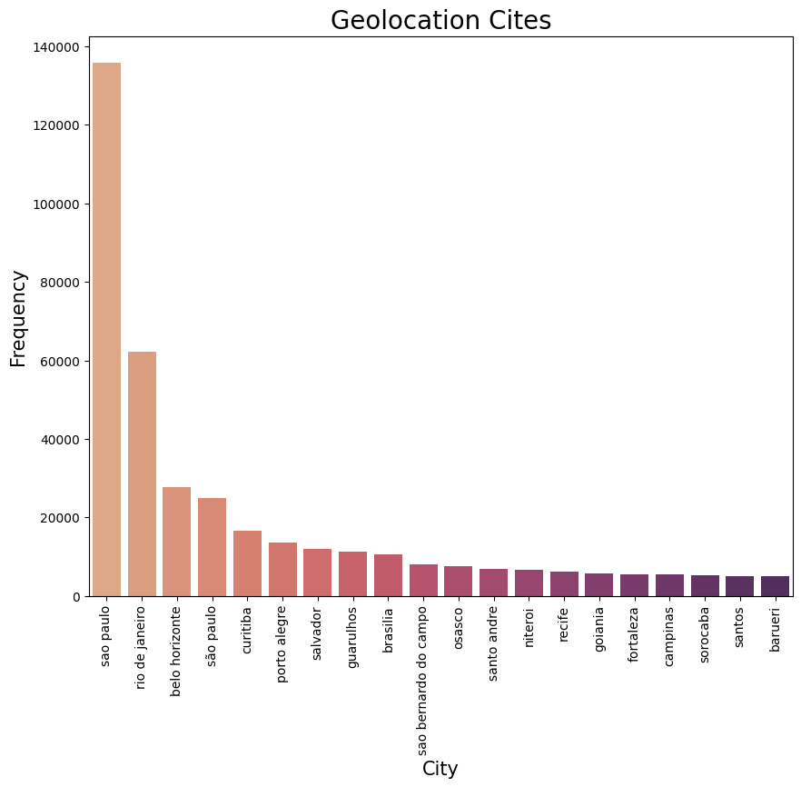

```python
top_20_geo_cities = geolocation_df['geolocation_city'].value_counts().head(20)
plt.figure(figsize=(10,8))
x = top_20_geo_cities.index
y = top_20_geo_cities.values
sns.barplot(x=x, y=y, palette='flare')
plt.xticks(rotation='vertical')
plt.title('Geolocation Cites', fontsize=20)
plt.xlabel('City', fontsize=15)
plt.ylabel('Frequency', fontsize=15)
plt.show()
```

```python
# Convert the zip code prefix to string
ecommerce_df['customer_zip_code_prefix'] = ecommerce_df['customer_zip_code_prefix'].astype(str)
ecommerce_df['customer_zip_code_prefix_3_digits'] = ecommerce_df['customer_zip_code_prefix'].str[:3]
ecommerce_df['customer_zip_code_prefix_3_digits'] = pd.to_numeric(ecommerce_df['customer_zip_code_prefix_3_digits'], errors='coerce')
ecommerce_df['customer_zip_code_prefix_3_digits'] = ecommerce_df['customer_zip_code_prefix_3_digits'].astype(int)
```

```python
ecommerce_df['order_delivered_customer_date'] = pd.to_datetime(ecommerce_df['order_delivered_customer_date'])
ecommerce_df['order_estimated_delivery_date'] = pd.to_datetime(ecommerce_df['order_estimated_delivery_date'])
ecommerce_df['order_delivered_carrier_date'] = pd.to_datetime(ecommerce_df['order_delivered_carrier_date'])
ecommerce_df['actual_delivery_time'] = ecommerce_df['order_delivered_customer_date'] - ecommerce_df['order_delivered_carrier_date']
ecommerce_df['actual_delivery_time'] = ecommerce_df['actual_delivery_time'].dt.days
```

```python
geolocation_df['geolocation_zip_code_prefix'] = geolocation_df['geolocation_zip_code_prefix'].astype(str)
geolocation_df['geolocation_zip_code_prefix_3_digits'] = geolocation_df['geolocation_zip_code_prefix'].str[:3]
geolocation_df['geolocation_zip_code_prefix_3_digits'] = pd.to_numeric(geolocation_df['geolocation_zip_code_prefix_3_digits'], errors='coerce')
geolocation_df['geolocation_zip_code_prefix_3_digits'] = geolocation_df['geolocation_zip_code_prefix_3_digits'].astype(int)
#pr = geolocation_df[geolocation_df['geolocation_state'] == 'PR']
brazil_geo_loc = geolocation_df.set_index('geolocation_zip_code_prefix_3_digits')
gp = ecommerce_df.groupby('customer_zip_code_prefix_3_digits')['actual_delivery_time'].mean().to_frame()
delivery_time = brazil_geo_loc.join(gp)
delivery_time['avg_delivery_time'] = delivery_time['actual_delivery_time']
```

```python
geolocation_df.head()
```

|  | geolocation_zip_code_prefix | geolocation_lat | geolocation_lng | geolocation_city | geolocation_state | x | y | geolocation_zip_code_prefix_3_digits |
| --- | --- | --- | --- | --- | --- | --- | --- | --- |
| 0 | 1037 | -23.545621 | -46.639292 | sao paulo | SP | -5.191862e+06 | -2.698137e+06 | 103 |
| 1 | 1046 | -23.546081 | -46.644820 | sao paulo | SP | -5.192478e+06 | -2.698193e+06 | 104 |
| 2 | 1046 | -23.546129 | -46.642951 | sao paulo | SP | -5.192270e+06 | -2.698199e+06 | 104 |
| 3 | 1041 | -23.544392 | -46.639499 | sao paulo | SP | -5.191885e+06 | -2.697988e+06 | 104 |
| 4 | 1035 | -23.541578 | -46.641607 | sao paulo | SP | -5.192120e+06 | -2.697646e+06 | 103 |

```python
delivery_time.head()
```

| geolocation_zip_code_prefix_3_digits | geolocation_zip_code_prefix | geolocation_lat | geolocation_lng | geolocation_city | geolocation_state | x | y | actual_delivery_time | avg_delivery_time |
| --- | --- | --- | --- | --- | --- | --- | --- | --- | --- |
| 100 | 1009 | -23.546935 | -46.636588 | sao paulo | SP | -5.191561e+06 | -2.698297e+06 | 2.925926 | 2.925926 |
| 100 | 1009 | -23.545430 | -46.635715 | sao paulo | SP | -5.191464e+06 | -2.698114e+06 | 2.925926 | 2.925926 |
| 100 | 1007 | -23.550393 | -46.637302 | sao paulo | SP | -5.191641e+06 | -2.698716e+06 | 2.925926 | 2.925926 |
| 100 | 1005 | -23.549819 | -46.635606 | sao paulo | SP | -5.191452e+06 | -2.698647e+06 | 2.925926 | 2.925926 |
| 100 | 1009 | -23.545692 | -46.635866 | sao paulo | SP | -5.191481e+06 | -2.698146e+06 | 2.925926 | 2.925926 |

# 3. Data Preprocessing

## 3.1. Drop duplicates in the dataset

```python
print("Number of rows:", len(ecommerce_df.index))
ecommerce_df.drop_duplicates(inplace=True)
print("Number of rows after drop of duplicates:", len(ecommerce_df.index))
```

```
Number of rows: 119143
Number of rows after drop of duplicates: 119143
```

## 3.2. Check for missing values in the dataset

```python
# Checking for missing values
ecommerce_df.isnull().sum()
```

```
order_id                                  0
customer_id                               0
order_status                              0
order_purchase_timestamp                  0
order_approved_at                       177
order_delivered_carrier_date           2086
order_delivered_customer_date          3421
order_estimated_delivery_date             0
order_item_id                           833
product_id                              833
seller_id                               833
shipping_limit_date                     833
price                                   833
freight_value                           833
payment_sequential                        3
payment_type                              3
payment_installments                      3
payment_value                             3
review_id                               997
review_score                            997
review_comment_title                 105154
review_comment_message                68898
review_creation_date                    997
review_answer_timestamp                 997
product_category_name                  2542
product_name_lenght                    2542
product_description_lenght             2542
product_photos_qty                     2542
product_weight_g                        853
product_length_cm                       853
product_height_cm                       853
product_width_cm                        853
customer_unique_id                        0
customer_zip_code_prefix                  0
customer_city                             0
customer_state                            0
seller_zip_code_prefix                  833
seller_city                             833
seller_state                            833
product_category_name_english          2567
customer_zip_code_prefix_3_digits         0
actual_delivery_time                   3422
dtype: int64
```

```python
missing = pd.DataFrame(ecommerce_df.isnull().sum()).reset_index()
missing.columns = ['Feature', 'Missing_Percent(%)']
missing['Missing_Percent(%)'] = missing['Missing_Percent(%)'].apply(lambda x: x / ecommerce_df.shape[0] * 100)
missing.loc[missing['Missing_Percent(%)']>0,:]
```

|  | Feature | Missing_Percent(%) |
| --- | --- | --- |
| 4 | order_approved_at | 0.148561 |
| 5 | order_delivered_carrier_date | 1.750837 |
| 6 | order_delivered_customer_date | 2.871339 |
| 8 | order_item_id | 0.699160 |
| 9 | product_id | 0.699160 |
| 10 | seller_id | 0.699160 |
| 11 | shipping_limit_date | 0.699160 |
| 12 | price | 0.699160 |
| 13 | freight_value | 0.699160 |
| 14 | payment_sequential | 0.002518 |
| 15 | payment_type | 0.002518 |
| 16 | payment_installments | 0.002518 |
| 17 | payment_value | 0.002518 |
| 18 | review_id | 0.836810 |
| 19 | review_score | 0.836810 |
| 20 | review_comment_title | 88.258647 |
| 21 | review_comment_message | 57.827988 |
| 22 | review_creation_date | 0.836810 |
| 23 | review_answer_timestamp | 0.836810 |
| 24 | product_category_name | 2.133571 |
| 25 | product_name_lenght | 2.133571 |
| 26 | product_description_lenght | 2.133571 |
| 27 | product_photos_qty | 2.133571 |
| 28 | product_weight_g | 0.715946 |
| 29 | product_length_cm | 0.715946 |
| 30 | product_height_cm | 0.715946 |
| 31 | product_width_cm | 0.715946 |
| 36 | seller_zip_code_prefix | 0.699160 |
| 37 | seller_city | 0.699160 |
| 38 | seller_state | 0.699160 |
| 39 | product_category_name_english | 2.154554 |
| 41 | actual_delivery_time | 2.872179 |

- review_comment_title and review_comment_message have a significant amount of missing data, with 88.26% and 57.83% missing respectively.
- payment_sequential, payment_type, payment_installments, and payment_value have very few missing values (less than 0.01%).
- Other features have less than 3% missing values.

## 3.3. Handling with missing values in the dataset

```python
# Drop columns with high missing values
ecommerce_df = ecommerce_df.drop(columns=['review_comment_title', 'review_comment_message'])

# Since we have less than 3% missing values in other columns, we will just remove the rows which have missing values using the dropna() function .
ecommerce_df = ecommerce_df.dropna()

# Verify missing values are handled
print(ecommerce_df.isnull().sum())
```

```
order_id                             0
customer_id                          0
order_status                         0
order_purchase_timestamp             0
order_approved_at                    0
order_delivered_carrier_date         0
order_delivered_customer_date        0
order_estimated_delivery_date        0
order_item_id                        0
product_id                           0
seller_id                            0
shipping_limit_date                  0
price                                0
freight_value                        0
payment_sequential                   0
payment_type                         0
payment_installments                 0
payment_value                        0
review_id                            0
review_score                         0
review_creation_date                 0
review_answer_timestamp              0
product_category_name                0
product_name_lenght                  0
product_description_lenght           0
product_photos_qty                   0
product_weight_g                     0
product_length_cm                    0
product_height_cm                    0
product_width_cm                     0
customer_unique_id                   0
customer_zip_code_prefix             0
customer_city                        0
customer_state                       0
seller_zip_code_prefix               0
seller_city                          0
seller_state                         0
product_category_name_english        0
customer_zip_code_prefix_3_digits    0
actual_delivery_time                 0
dtype: int64
```

```python
ecommerce_df.shape
```

```
(113193, 40)
```

## 3.4. Correcting datatypes

```python
columns_timestamp = ['order_purchase_timestamp','order_approved_at',
                     'order_delivered_carrier_date', 'order_delivered_customer_date', 'order_estimated_delivery_date']
for column in columns_timestamp:
    ecommerce_df[column] = pd.to_datetime(ecommerce_df[column])
```

## 3.5. Encode categorical variables into a numerical format using techniques like one-hot encoding or label encoding.

### 3.5.1. Data before the encode

```python
display(ecommerce_df)
```

|  | order_id | customer_id | order_status | order_purchase_timestamp | order_approved_at | order_delivered_carrier_date | order_delivered_customer_date | order_estimated_delivery_date | order_item_id | product_id | ... | customer_unique_id | customer_zip_code_prefix | customer_city | customer_state | seller_zip_code_prefix | seller_city | seller_state | product_category_name_english | customer_zip_code_prefix_3_digits | actual_delivery_time |
| --- | --- | --- | --- | --- | --- | --- | --- | --- | --- | --- | --- | --- | --- | --- | --- | --- | --- | --- | --- | --- | --- |
| 0 | e481f51cbdc54678b7cc49136f2d6af7 | 9ef432eb6251297304e76186b10a928d | delivered | 2017-10-02 10:56:33 | 2017-10-02 11:07:15 | 2017-10-04 19:55:00 | 2017-10-10 21:25:13 | 2017-10-18 | 1.0 | 87285b34884572647811a353c7ac498a | ... | 7c396fd4830fd04220f754e42b4e5bff | 3149 | sao paulo | SP | 9350.0 | maua | SP | housewares | 314 | 6.0 |
| 1 | e481f51cbdc54678b7cc49136f2d6af7 | 9ef432eb6251297304e76186b10a928d | delivered | 2017-10-02 10:56:33 | 2017-10-02 11:07:15 | 2017-10-04 19:55:00 | 2017-10-10 21:25:13 | 2017-10-18 | 1.0 | 87285b34884572647811a353c7ac498a | ... | 7c396fd4830fd04220f754e42b4e5bff | 3149 | sao paulo | SP | 9350.0 | maua | SP | housewares | 314 | 6.0 |
| 2 | e481f51cbdc54678b7cc49136f2d6af7 | 9ef432eb6251297304e76186b10a928d | delivered | 2017-10-02 10:56:33 | 2017-10-02 11:07:15 | 2017-10-04 19:55:00 | 2017-10-10 21:25:13 | 2017-10-18 | 1.0 | 87285b34884572647811a353c7ac498a | ... | 7c396fd4830fd04220f754e42b4e5bff | 3149 | sao paulo | SP | 9350.0 | maua | SP | housewares | 314 | 6.0 |
| 3 | 128e10d95713541c87cd1a2e48201934 | a20e8105f23924cd00833fd87daa0831 | delivered | 2017-08-15 18:29:31 | 2017-08-15 20:05:16 | 2017-08-17 15:28:33 | 2017-08-18 14:44:43 | 2017-08-28 | 1.0 | 87285b34884572647811a353c7ac498a | ... | 3a51803cc0d012c3b5dc8b7528cb05f7 | 3366 | sao paulo | SP | 9350.0 | maua | SP | housewares | 336 | 0.0 |
| 4 | 0e7e841ddf8f8f2de2bad69267ecfbcf | 26c7ac168e1433912a51b924fbd34d34 | delivered | 2017-08-02 18:24:47 | 2017-08-02 18:43:15 | 2017-08-04 17:35:43 | 2017-08-07 18:30:01 | 2017-08-15 | 1.0 | 87285b34884572647811a353c7ac498a | ... | ef0996a1a279c26e7ecbd737be23d235 | 2290 | sao paulo | SP | 9350.0 | maua | SP | housewares | 229 | 3.0 |
| ... | ... | ... | ... | ... | ... | ... | ... | ... | ... | ... | ... | ... | ... | ... | ... | ... | ... | ... | ... | ... | ... |
| 119136 | 872b07190c0c9c0f13475d2141c4036a | 814605f2161337c56520639099b0199f | delivered | 2018-07-03 10:10:12 | 2018-07-05 16:22:38 | 2018-07-03 12:00:00 | 2018-07-10 17:18:49 | 2018-08-02 | 2.0 | 97de49733ccaac64d122444d8db709d1 | ... | c5df80808db02b2e08abd92b9d964b9b | 66033 | belem | PA | 5201.0 | sao paulo | SP | books_imported | 660 | 7.0 |
| 119137 | 522eec5aa38ae3153b1c1a94e013947e | 39eda8beee70b851aa9ba9040fb44615 | delivered | 2018-07-05 16:25:40 | 2018-07-06 02:35:18 | 2018-07-06 10:27:00 | 2018-07-09 18:16:53 | 2018-07-27 | 1.0 | 5b668636d65ddf4e4109c6d8fb13ea56 | ... | 9790c90c5b3a1a5237c11433331af1cb | 83206 | paranagua | PR | 5201.0 | sao paulo | SP | books_imported | 832 | 3.0 |
| 119139 | 1dbff949801376b8795a093d31cfe205 | 0cbd2df3d6e9d8b1eaf5cfefc44886bc | delivered | 2018-05-16 14:50:54 | 2018-05-16 15:18:42 | 2018-05-18 12:10:00 | 2018-05-21 17:14:08 | 2018-05-28 | 1.0 | 90797f195eb7bb9dae050697a25f35ce | ... | 1de8fb735d8252498d9a2f82a68c57e0 | 9411 | ribeirao pires | SP | 5201.0 | sao paulo | SP | books_imported | 941 | 3.0 |
| 119140 | 6775b950cdc4da0ce39b261032f92c84 | c4d135422be0d4333f506acde8af9419 | delivered | 2018-06-13 12:19:26 | 2018-06-13 17:39:14 | 2018-06-15 13:09:00 | 2018-06-16 17:48:30 | 2018-06-28 | 1.0 | 3e72533d34a1779d818ac8a73403387c | ... | 5f684afb3d1a02f2787e80cb0eee6e02 | 2927 | sao paulo | SP | 5201.0 | sao paulo | SP | books_imported | 292 | 1.0 |
| 119141 | 73d60420cd1a179b2d8887d538efe4c2 | 65d9213dfa004c17dc126503e106e4a3 | delivered | 2018-08-07 10:52:58 | 2018-08-07 11:05:18 | 2018-08-08 08:31:00 | 2018-08-22 17:02:23 | 2018-09-04 | 1.0 | 078b7149a32b479d3cbf1649fea0172c | ... | 78275e95a4296105923051e0ad4577b3 | 65700 | bacabal | MA | 22745.0 | rio de janeiro | RJ | books_imported | 657 | 14.0 |

113193 rows × 40 columns

To encode categorical variables in your ecommerce_df dataset, we can use techniques like one-hot encoding or label encoding.

First, we will identify the categorical variables in your dataset:

1. order_status
2. payment_type
3. product_category_name
4. customer_city
5. customer_state
6. seller_city
7. eller_state
8. product_category_name_english

In our case we will use label encoding:

```python
import pandas as pd
from sklearn.preprocessing import LabelEncoder

# Sample DataFrame (assuming ecommerce_df is already loaded as described)
# ecommerce_df = pd.read_csv('path_to_your_dataset.csv')

# Initialize the LabelEncoder
label_encoder = LabelEncoder()

# List of categorical columns to be encoded
categorical_columns = ['order_status', 'payment_type', 'product_category_name',
                       'customer_city', 'customer_state', 'seller_city',
                       'seller_state', 'product_category_name_english']

# Apply label encoding to each categorical column
for column in categorical_columns:
    ecommerce_df[column] = label_encoder.fit_transform(ecommerce_df[column].astype(str))
```

### 3.5.2. Data after the encode

```python
display(ecommerce_df)
```

|  | order_id | customer_id | order_status | order_purchase_timestamp | order_approved_at | order_delivered_carrier_date | order_delivered_customer_date | order_estimated_delivery_date | order_item_id | product_id | ... | customer_unique_id | customer_zip_code_prefix | customer_city | customer_state | seller_zip_code_prefix | seller_city | seller_state | product_category_name_english | customer_zip_code_prefix_3_digits | actual_delivery_time |
| --- | --- | --- | --- | --- | --- | --- | --- | --- | --- | --- | --- | --- | --- | --- | --- | --- | --- | --- | --- | --- | --- |
| 0 | e481f51cbdc54678b7cc49136f2d6af7 | 9ef432eb6251297304e76186b10a928d | 1 | 2017-10-02 10:56:33 | 2017-10-02 11:07:15 | 2017-10-04 19:55:00 | 2017-10-10 21:25:13 | 2017-10-18 | 1.0 | 87285b34884572647811a353c7ac498a | ... | 7c396fd4830fd04220f754e42b4e5bff | 3149 | 3552 | 25 | 9350.0 | 317 | 21 | 49 | 314 | 6.0 |
| 1 | e481f51cbdc54678b7cc49136f2d6af7 | 9ef432eb6251297304e76186b10a928d | 1 | 2017-10-02 10:56:33 | 2017-10-02 11:07:15 | 2017-10-04 19:55:00 | 2017-10-10 21:25:13 | 2017-10-18 | 1.0 | 87285b34884572647811a353c7ac498a | ... | 7c396fd4830fd04220f754e42b4e5bff | 3149 | 3552 | 25 | 9350.0 | 317 | 21 | 49 | 314 | 6.0 |
| 2 | e481f51cbdc54678b7cc49136f2d6af7 | 9ef432eb6251297304e76186b10a928d | 1 | 2017-10-02 10:56:33 | 2017-10-02 11:07:15 | 2017-10-04 19:55:00 | 2017-10-10 21:25:13 | 2017-10-18 | 1.0 | 87285b34884572647811a353c7ac498a | ... | 7c396fd4830fd04220f754e42b4e5bff | 3149 | 3552 | 25 | 9350.0 | 317 | 21 | 49 | 314 | 6.0 |
| 3 | 128e10d95713541c87cd1a2e48201934 | a20e8105f23924cd00833fd87daa0831 | 1 | 2017-08-15 18:29:31 | 2017-08-15 20:05:16 | 2017-08-17 15:28:33 | 2017-08-18 14:44:43 | 2017-08-28 | 1.0 | 87285b34884572647811a353c7ac498a | ... | 3a51803cc0d012c3b5dc8b7528cb05f7 | 3366 | 3552 | 25 | 9350.0 | 317 | 21 | 49 | 336 | 0.0 |
| 4 | 0e7e841ddf8f8f2de2bad69267ecfbcf | 26c7ac168e1433912a51b924fbd34d34 | 1 | 2017-08-02 18:24:47 | 2017-08-02 18:43:15 | 2017-08-04 17:35:43 | 2017-08-07 18:30:01 | 2017-08-15 | 1.0 | 87285b34884572647811a353c7ac498a | ... | ef0996a1a279c26e7ecbd737be23d235 | 2290 | 3552 | 25 | 9350.0 | 317 | 21 | 49 | 229 | 3.0 |
| ... | ... | ... | ... | ... | ... | ... | ... | ... | ... | ... | ... | ... | ... | ... | ... | ... | ... | ... | ... | ... | ... |
| 119136 | 872b07190c0c9c0f13475d2141c4036a | 814605f2161337c56520639099b0199f | 1 | 2018-07-03 10:10:12 | 2018-07-05 16:22:38 | 2018-07-03 12:00:00 | 2018-07-10 17:18:49 | 2018-08-02 | 2.0 | 97de49733ccaac64d122444d8db709d1 | ... | c5df80808db02b2e08abd92b9d964b9b | 66033 | 443 | 13 | 5201.0 | 497 | 21 | 9 | 660 | 7.0 |
| 119137 | 522eec5aa38ae3153b1c1a94e013947e | 39eda8beee70b851aa9ba9040fb44615 | 1 | 2018-07-05 16:25:40 | 2018-07-06 02:35:18 | 2018-07-06 10:27:00 | 2018-07-09 18:16:53 | 2018-07-27 | 1.0 | 5b668636d65ddf4e4109c6d8fb13ea56 | ... | 9790c90c5b3a1a5237c11433331af1cb | 83206 | 2657 | 17 | 5201.0 | 497 | 21 | 9 | 832 | 3.0 |
| 119139 | 1dbff949801376b8795a093d31cfe205 | 0cbd2df3d6e9d8b1eaf5cfefc44886bc | 1 | 2018-05-16 14:50:54 | 2018-05-16 15:18:42 | 2018-05-18 12:10:00 | 2018-05-21 17:14:08 | 2018-05-28 | 1.0 | 90797f195eb7bb9dae050697a25f35ce | ... | 1de8fb735d8252498d9a2f82a68c57e0 | 9411 | 3093 | 25 | 5201.0 | 497 | 21 | 9 | 941 | 3.0 |
| 119140 | 6775b950cdc4da0ce39b261032f92c84 | c4d135422be0d4333f506acde8af9419 | 1 | 2018-06-13 12:19:26 | 2018-06-13 17:39:14 | 2018-06-15 13:09:00 | 2018-06-16 17:48:30 | 2018-06-28 | 1.0 | 3e72533d34a1779d818ac8a73403387c | ... | 5f684afb3d1a02f2787e80cb0eee6e02 | 2927 | 3552 | 25 | 5201.0 | 497 | 21 | 9 | 292 | 1.0 |
| 119141 | 73d60420cd1a179b2d8887d538efe4c2 | 65d9213dfa004c17dc126503e106e4a3 | 1 | 2018-08-07 10:52:58 | 2018-08-07 11:05:18 | 2018-08-08 08:31:00 | 2018-08-22 17:02:23 | 2018-09-04 | 1.0 | 078b7149a32b479d3cbf1649fea0172c | ... | 78275e95a4296105923051e0ad4577b3 | 65700 | 342 | 9 | 22745.0 | 430 | 15 | 9 | 657 | 14.0 |

113193 rows × 40 columns

## 3.6. Scale numerical features to ensure they have similar ranges, which can improve the performance of ML algorithms.

To scale numerical features we can use techniques such as standardization (z-score normalization) or min-max scaling. This process can improve the performance of many machine learning algorithms by ensuring that the numerical features are on a similar scale.

```python
import pandas as pd
from sklearn.preprocessing import StandardScaler, MinMaxScaler

# List of numerical columns to be scaled
numerical_columns = ['order_item_id', 'price', 'freight_value', 'payment_sequential',
                     'payment_installments', 'payment_value', 'review_score',
                     'product_name_lenght', 'product_description_lenght',
                     'product_photos_qty', 'product_weight_g', 'product_length_cm',
                     'product_height_cm', 'product_width_cm']

# Drop rows with NaN values in numerical columns to avoid issues during scaling
ecommerce_df = ecommerce_df.dropna(subset=numerical_columns)

# Initialize the scalers
standard_scaler = StandardScaler()
minmax_scaler = MinMaxScaler()

# Apply standardization (z-score normalization)
ecommerce_df_standardized = ecommerce_df.copy()
ecommerce_df_standardized[numerical_columns] = standard_scaler.fit_transform(ecommerce_df_standardized[numerical_columns])

# Apply min-max scaling
ecommerce_df_minmax_scaled = ecommerce_df.copy()
ecommerce_df_minmax_scaled[numerical_columns] = minmax_scaler.fit_transform(ecommerce_df_minmax_scaled[numerical_columns])

# Display the first few rows of the scaled dataframes
print("Standardized Data:")
print(ecommerce_df_standardized.head())

print("\nMin-Max Scaled Data:")
print(ecommerce_df_minmax_scaled.head())
```

```
Standardized Data:
                           order_id                       customer_id
0  e481f51cbdc54678b7cc49136f2d6af7  9ef432eb6251297304e76186b10a928d  \
1  e481f51cbdc54678b7cc49136f2d6af7  9ef432eb6251297304e76186b10a928d
2  e481f51cbdc54678b7cc49136f2d6af7  9ef432eb6251297304e76186b10a928d
3  128e10d95713541c87cd1a2e48201934  a20e8105f23924cd00833fd87daa0831
4  0e7e841ddf8f8f2de2bad69267ecfbcf  26c7ac168e1433912a51b924fbd34d34

   order_status order_purchase_timestamp   order_approved_at
0             1      2017-10-02 10:56:33 2017-10-02 11:07:15  \
1             1      2017-10-02 10:56:33 2017-10-02 11:07:15
2             1      2017-10-02 10:56:33 2017-10-02 11:07:15
3             1      2017-08-15 18:29:31 2017-08-15 20:05:16
4             1      2017-08-02 18:24:47 2017-08-02 18:43:15

```

[output cut: 116 more lines]

# 4. Feature Engineering

## 4.1. Create new features such as calculating RFM (Recency, Frequency, Monetary) scores, deriving customer lifetime value (CLV), and extracting geographical features or transforming existing ones to facilitate segmentation.

1. Calculating RFM Scores

Recency: Time since the last purchase.  
Frequency: Number of purchases.  
Monetary: Total amount spent.

```python
import pandas as pd
import numpy as np

# Assuming ecommerce_df is already loaded as described
# Convert order_purchase_timestamp to datetime
ecommerce_df['order_purchase_timestamp'] = pd.to_datetime(ecommerce_df['order_purchase_timestamp'])

# Define the reference date (usually the most recent purchase date in the dataset)
reference_date = ecommerce_df['order_purchase_timestamp'].max()

# Calculate Recency, Frequency, and Monetary
rfm_df = ecommerce_df.groupby('customer_id').agg({
    'order_purchase_timestamp': lambda x: (reference_date - x.max()).days,  # Recency
    'order_id': 'count',  # Frequency
    'payment_value': 'sum'  # Monetary
}).reset_index()

# Rename the columns
rfm_df.columns = ['customer_id', 'recency', 'frequency', 'monetary']

print(rfm_df.head())
```

```
                        customer_id  recency  frequency  monetary
0  00012a2ce6f8dcda20d059ce98491703      287          1    114.74
1  000161a058600d5901f007fab4c27140      409          1     67.41
2  0001fd6190edaaf884bcaf3d49edf079      547          1    195.42
3  0002414f95344307404f0ace7a26f1d5      378          1    179.35
4  000379cdec625522490c315e70c7a9fb      149          1    107.01
```

2. Deriving Customer Lifetime Value (CLV)

Customer Lifetime Value can be derived using the formula:

- CLV=Average Purchase Value×Purchase Frequency×Customer Lifespan

```python
# Calculate average purchase value
rfm_df['avg_purchase_value'] = rfm_df['monetary'] / rfm_df['frequency']

# Estimate customer lifespan (in days) as the time between the first and last purchase
customer_lifespan = ecommerce_df.groupby('customer_id').agg({
    'order_purchase_timestamp': lambda x: (x.max() - x.min()).days
}).reset_index()

customer_lifespan.columns = ['customer_id', 'customer_lifespan']

# Merge RFM with customer lifespan
rfm_clv_df = pd.merge(rfm_df, customer_lifespan, on='customer_id')

# Calculate CLV
rfm_clv_df['clv'] = rfm_clv_df['avg_purchase_value'] * rfm_clv_df['frequency'] * rfm_clv_df['customer_lifespan']

print(rfm_clv_df.head())
```

```
                        customer_id  recency  frequency  monetary
0  00012a2ce6f8dcda20d059ce98491703      287          1    114.74  \
1  000161a058600d5901f007fab4c27140      409          1     67.41
2  0001fd6190edaaf884bcaf3d49edf079      547          1    195.42
3  0002414f95344307404f0ace7a26f1d5      378          1    179.35
4  000379cdec625522490c315e70c7a9fb      149          1    107.01

   avg_purchase_value  customer_lifespan  clv
0              114.74                  0  0.0
1               67.41                  0  0.0
2              195.42                  0  0.0
3              179.35                  0  0.0
4              107.01                  0  0.0
```

3. Facilitating Segmentation

Here we will Combine RFM, CLV, and geographical features for segmentation.

```python
display(ecommerce_df)
```

|  | order_id | customer_id | order_status | order_purchase_timestamp | order_approved_at | order_delivered_carrier_date | order_delivered_customer_date | order_estimated_delivery_date | order_item_id | product_id | ... | customer_unique_id | customer_zip_code_prefix | customer_city | customer_state | seller_zip_code_prefix | seller_city | seller_state | product_category_name_english | customer_zip_code_prefix_3_digits | actual_delivery_time |
| --- | --- | --- | --- | --- | --- | --- | --- | --- | --- | --- | --- | --- | --- | --- | --- | --- | --- | --- | --- | --- | --- |
| 0 | e481f51cbdc54678b7cc49136f2d6af7 | 9ef432eb6251297304e76186b10a928d | 1 | 2017-10-02 10:56:33 | 2017-10-02 11:07:15 | 2017-10-04 19:55:00 | 2017-10-10 21:25:13 | 2017-10-18 | 1.0 | 87285b34884572647811a353c7ac498a | ... | 7c396fd4830fd04220f754e42b4e5bff | 3149 | 2838 | 18 | 9350.0 | 243 | 14 | 49 | 314 | 6.0 |
| 1 | e481f51cbdc54678b7cc49136f2d6af7 | 9ef432eb6251297304e76186b10a928d | 1 | 2017-10-02 10:56:33 | 2017-10-02 11:07:15 | 2017-10-04 19:55:00 | 2017-10-10 21:25:13 | 2017-10-18 | 1.0 | 87285b34884572647811a353c7ac498a | ... | 7c396fd4830fd04220f754e42b4e5bff | 3149 | 2838 | 18 | 9350.0 | 243 | 14 | 49 | 314 | 6.0 |
| 2 | e481f51cbdc54678b7cc49136f2d6af7 | 9ef432eb6251297304e76186b10a928d | 1 | 2017-10-02 10:56:33 | 2017-10-02 11:07:15 | 2017-10-04 19:55:00 | 2017-10-10 21:25:13 | 2017-10-18 | 1.0 | 87285b34884572647811a353c7ac498a | ... | 7c396fd4830fd04220f754e42b4e5bff | 3149 | 2838 | 18 | 9350.0 | 243 | 14 | 49 | 314 | 6.0 |
| 3 | 128e10d95713541c87cd1a2e48201934 | a20e8105f23924cd00833fd87daa0831 | 1 | 2017-08-15 18:29:31 | 2017-08-15 20:05:16 | 2017-08-17 15:28:33 | 2017-08-18 14:44:43 | 2017-08-28 | 1.0 | 87285b34884572647811a353c7ac498a | ... | 3a51803cc0d012c3b5dc8b7528cb05f7 | 3366 | 2838 | 18 | 9350.0 | 243 | 14 | 49 | 336 | 0.0 |
| 4 | 0e7e841ddf8f8f2de2bad69267ecfbcf | 26c7ac168e1433912a51b924fbd34d34 | 1 | 2017-08-02 18:24:47 | 2017-08-02 18:43:15 | 2017-08-04 17:35:43 | 2017-08-07 18:30:01 | 2017-08-15 | 1.0 | 87285b34884572647811a353c7ac498a | ... | ef0996a1a279c26e7ecbd737be23d235 | 2290 | 2838 | 18 | 9350.0 | 243 | 14 | 49 | 229 | 3.0 |
| ... | ... | ... | ... | ... | ... | ... | ... | ... | ... | ... | ... | ... | ... | ... | ... | ... | ... | ... | ... | ... | ... |
| 119136 | 872b07190c0c9c0f13475d2141c4036a | 814605f2161337c56520639099b0199f | 1 | 2018-07-03 10:10:12 | 2018-07-05 16:22:38 | 2018-07-03 12:00:00 | 2018-07-10 17:18:49 | 2018-08-02 | 2.0 | 97de49733ccaac64d122444d8db709d1 | ... | c5df80808db02b2e08abd92b9d964b9b | 66033 | 3454 | 5 | 5201.0 | 442 | 14 | 9 | 660 | 7.0 |
| 119137 | 522eec5aa38ae3153b1c1a94e013947e | 39eda8beee70b851aa9ba9040fb44615 | 1 | 2018-07-05 16:25:40 | 2018-07-06 02:35:18 | 2018-07-06 10:27:00 | 2018-07-09 18:16:53 | 2018-07-27 | 1.0 | 5b668636d65ddf4e4109c6d8fb13ea56 | ... | 9790c90c5b3a1a5237c11433331af1cb | 83206 | 1843 | 9 | 5201.0 | 442 | 14 | 9 | 832 | 3.0 |
| 119139 | 1dbff949801376b8795a093d31cfe205 | 0cbd2df3d6e9d8b1eaf5cfefc44886bc | 1 | 2018-05-16 14:50:54 | 2018-05-16 15:18:42 | 2018-05-18 12:10:00 | 2018-05-21 17:14:08 | 2018-05-28 | 1.0 | 90797f195eb7bb9dae050697a25f35ce | ... | 1de8fb735d8252498d9a2f82a68c57e0 | 9411 | 2328 | 18 | 5201.0 | 442 | 14 | 9 | 941 | 3.0 |
| 119140 | 6775b950cdc4da0ce39b261032f92c84 | c4d135422be0d4333f506acde8af9419 | 1 | 2018-06-13 12:19:26 | 2018-06-13 17:39:14 | 2018-06-15 13:09:00 | 2018-06-16 17:48:30 | 2018-06-28 | 1.0 | 3e72533d34a1779d818ac8a73403387c | ... | 5f684afb3d1a02f2787e80cb0eee6e02 | 2927 | 2838 | 18 | 5201.0 | 442 | 14 | 9 | 292 | 1.0 |
| 119141 | 73d60420cd1a179b2d8887d538efe4c2 | 65d9213dfa004c17dc126503e106e4a3 | 1 | 2018-08-07 10:52:58 | 2018-08-07 11:05:18 | 2018-08-08 08:31:00 | 2018-08-22 17:02:23 | 2018-09-04 | 1.0 | 078b7149a32b479d3cbf1649fea0172c | ... | 78275e95a4296105923051e0ad4577b3 | 65700 | 2691 | 26 | 22745.0 | 369 | 7 | 9 | 657 | 14.0 |

113193 rows × 40 columns

```python
# Merge RFM and CLV features back to the main dataframe
ecommerce_df = pd.merge(ecommerce_df, rfm_clv_df[['customer_id', 'recency', 'frequency', 'monetary', 'clv']], on='customer_id', how='left')
```

```python
ecommerce_df
```

|  | order_id | customer_id | order_status | order_purchase_timestamp | order_approved_at | order_delivered_carrier_date | order_delivered_customer_date | order_estimated_delivery_date | order_item_id | product_id | ... | seller_zip_code_prefix | seller_city | seller_state | product_category_name_english | customer_zip_code_prefix_3_digits | actual_delivery_time | recency | frequency | monetary | clv |
| --- | --- | --- | --- | --- | --- | --- | --- | --- | --- | --- | --- | --- | --- | --- | --- | --- | --- | --- | --- | --- | --- |
| 0 | e481f51cbdc54678b7cc49136f2d6af7 | 9ef432eb6251297304e76186b10a928d | 1 | 2017-10-02 10:56:33 | 2017-10-02 11:07:15 | 2017-10-04 19:55:00 | 2017-10-10 21:25:13 | 2017-10-18 | 1.0 | 87285b34884572647811a353c7ac498a | ... | 9350.0 | 243 | 14 | 49 | 314 | 6.0 | 331 | 3 | 38.71 | 0.0 |
| 1 | e481f51cbdc54678b7cc49136f2d6af7 | 9ef432eb6251297304e76186b10a928d | 1 | 2017-10-02 10:56:33 | 2017-10-02 11:07:15 | 2017-10-04 19:55:00 | 2017-10-10 21:25:13 | 2017-10-18 | 1.0 | 87285b34884572647811a353c7ac498a | ... | 9350.0 | 243 | 14 | 49 | 314 | 6.0 | 331 | 3 | 38.71 | 0.0 |
| 2 | e481f51cbdc54678b7cc49136f2d6af7 | 9ef432eb6251297304e76186b10a928d | 1 | 2017-10-02 10:56:33 | 2017-10-02 11:07:15 | 2017-10-04 19:55:00 | 2017-10-10 21:25:13 | 2017-10-18 | 1.0 | 87285b34884572647811a353c7ac498a | ... | 9350.0 | 243 | 14 | 49 | 314 | 6.0 | 331 | 3 | 38.71 | 0.0 |
| 3 | 128e10d95713541c87cd1a2e48201934 | a20e8105f23924cd00833fd87daa0831 | 1 | 2017-08-15 18:29:31 | 2017-08-15 20:05:16 | 2017-08-17 15:28:33 | 2017-08-18 14:44:43 | 2017-08-28 | 1.0 | 87285b34884572647811a353c7ac498a | ... | 9350.0 | 243 | 14 | 49 | 336 | 0.0 | 378 | 1 | 37.77 | 0.0 |
| 4 | 0e7e841ddf8f8f2de2bad69267ecfbcf | 26c7ac168e1433912a51b924fbd34d34 | 1 | 2017-08-02 18:24:47 | 2017-08-02 18:43:15 | 2017-08-04 17:35:43 | 2017-08-07 18:30:01 | 2017-08-15 | 1.0 | 87285b34884572647811a353c7ac498a | ... | 9350.0 | 243 | 14 | 49 | 229 | 3.0 | 391 | 1 | 37.77 | 0.0 |
| ... | ... | ... | ... | ... | ... | ... | ... | ... | ... | ... | ... | ... | ... | ... | ... | ... | ... | ... | ... | ... | ... |
| 113188 | 872b07190c0c9c0f13475d2141c4036a | 814605f2161337c56520639099b0199f | 1 | 2018-07-03 10:10:12 | 2018-07-05 16:22:38 | 2018-07-03 12:00:00 | 2018-07-10 17:18:49 | 2018-08-02 | 2.0 | 97de49733ccaac64d122444d8db709d1 | ... | 5201.0 | 442 | 14 | 9 | 660 | 7.0 | 57 | 2 | 337.44 | 0.0 |
| 113189 | 522eec5aa38ae3153b1c1a94e013947e | 39eda8beee70b851aa9ba9040fb44615 | 1 | 2018-07-05 16:25:40 | 2018-07-06 02:35:18 | 2018-07-06 10:27:00 | 2018-07-09 18:16:53 | 2018-07-27 | 1.0 | 5b668636d65ddf4e4109c6d8fb13ea56 | ... | 5201.0 | 442 | 14 | 9 | 832 | 3.0 | 54 | 1 | 63.41 | 0.0 |
| 113190 | 1dbff949801376b8795a093d31cfe205 | 0cbd2df3d6e9d8b1eaf5cfefc44886bc | 1 | 2018-05-16 14:50:54 | 2018-05-16 15:18:42 | 2018-05-18 12:10:00 | 2018-05-21 17:14:08 | 2018-05-28 | 1.0 | 90797f195eb7bb9dae050697a25f35ce | ... | 5201.0 | 442 | 14 | 9 | 941 | 3.0 | 105 | 1 | 66.38 | 0.0 |
| 113191 | 6775b950cdc4da0ce39b261032f92c84 | c4d135422be0d4333f506acde8af9419 | 1 | 2018-06-13 12:19:26 | 2018-06-13 17:39:14 | 2018-06-15 13:09:00 | 2018-06-16 17:48:30 | 2018-06-28 | 1.0 | 3e72533d34a1779d818ac8a73403387c | ... | 5201.0 | 442 | 14 | 9 | 292 | 1.0 | 77 | 1 | 31.42 | 0.0 |
| 113192 | 73d60420cd1a179b2d8887d538efe4c2 | 65d9213dfa004c17dc126503e106e4a3 | 1 | 2018-08-07 10:52:58 | 2018-08-07 11:05:18 | 2018-08-08 08:31:00 | 2018-08-22 17:02:23 | 2018-09-04 | 1.0 | 078b7149a32b479d3cbf1649fea0172c | ... | 22745.0 | 369 | 7 | 9 | 657 | 14.0 | 22 | 1 | 804.96 | 0.0 |

113193 rows × 44 columns

```python
# Perform segmentation, for example, using KMeans clustering
from sklearn.cluster import KMeans

# Selecting features for clustering
features_for_clustering = ['recency', 'frequency', 'monetary', 'customer_city', 'customer_state','actual_delivery_time','review_score']

# Standardize the features
from sklearn.preprocessing import StandardScaler

scaler = StandardScaler()
scaled_features = scaler.fit_transform(ecommerce_df[features_for_clustering])
```

```python
scaled_features_df= pd.DataFrame(scaled_features)
```

```python
scaled_features_df.columns = ['recency', 'frequency', 'monetary', 'customer_city', 'customer_state','actual_delivery_time','review_score']
display(scaled_features_df)
```

|  | recency | frequency | monetary | customer_city | customer_state | actual_delivery_time | review_score |
| --- | --- | --- | --- | --- | --- | --- | --- |
| 0 | 0.596580 | 0.561873 | -0.206114 | 0.550941 | 0.589439 | -0.317834 | -0.061300 |
| 1 | 0.596580 | 0.561873 | -0.206114 | 0.550941 | 0.589439 | -0.317834 | -0.061300 |
| 2 | 0.596580 | 0.561873 | -0.206114 | 0.550941 | 0.589439 | -0.317834 | -0.061300 |
| 3 | 0.903951 | -0.278475 | -0.206741 | 0.550941 | 0.589439 | -1.020318 | -0.061300 |
| 4 | 0.988969 | -0.278475 | -0.206741 | 0.550941 | 0.589439 | -0.669076 | 0.681687 |
| ... | ... | ... | ... | ... | ... | ... | ... |
| 113188 | -1.195328 | 0.141699 | -0.006941 | 1.128833 | -1.424775 | -0.200754 | 0.681687 |
| 113189 | -1.214948 | -0.278475 | -0.189646 | -0.382505 | -0.805017 | -0.669076 | -2.290263 |
| 113190 | -0.881417 | -0.278475 | -0.187665 | 0.072491 | 0.589439 | -0.669076 | 0.681687 |
| 113191 | -1.064532 | -0.278475 | -0.210974 | 0.550941 | 0.589439 | -0.903237 | 0.681687 |
| 113192 | -1.424222 | -0.278475 | 0.304771 | 0.413035 | 1.828955 | 0.618810 | 0.681687 |

113193 rows × 7 columns

# 5. Cluster analysis

```python
pip install yellowbrick
```

## 5.1. Determining the optimal number of clusters using the elbow method with Yellowbrick's

[output not shown]

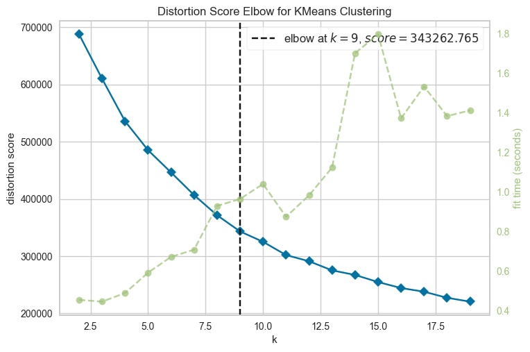

```python
from sklearn.cluster import KMeans
from yellowbrick.cluster import KElbowVisualizer
k_means = KMeans()
elbow = KElbowVisualizer(k_means, k=(2, 20))
elbow.fit(scaled_features_df)
elbow.show()
```